# Location & Date reporting bias

## Rates of missing observations by variable

FTE Days Lost: 0%

Absence Category: 0%

Absence Type: 0%

Absence Reason: 0%

Level 2 Reason: 99.774%

Surgery Related: 99.99%

Absence End Date: 0%

Working Days Lost: 0%

Hours Lost: 0%

Predicted Fitness Date: 99.983%

Work Related: 3.573%

Third Party: 99.986%

RTW Discussion Date: 87.386%

Occ Health Referral Date: 98.553%

Related Reason: 99.781%

Days to Enter: 0%

Classification: 0%

Total Duration (Days): 0%

Sessions Lost: 0%

Certification Type: 0%

Assessment Date: 99.997%

Disability Related: 99.99%

Violence Related: 99.99%

Notifiable Disease: 99.99%

Org L3: 12.974%

Org L4: 12.974%

Org L7: 12.974%

Column 28: 100%

Role: 12.974%

Calendar Days Lost: 0%

Absence Estimated Cost: 0%

FTE: 0%

Assignment Category: 12.974%

Primary Assignment: 0%

Assignment Status: 12.974%

Work at Home Flag: 0%

Half Pay Nil Pay: 100%

Sickness Absence Half Pay Start Date: 100%

Sickness Absence Nil Pay Start Date: 100%

Days to Half Pay: 100%

Days to Nil Pay: 100%

Occupation Code: 12.974%

Position Title: 12.974%

Pay Scale: 12.974%

Prorated: 93.866%

First Day Absent: 0%

Total FTE Calendar Days : 0%

Actual Termination Date: 61.851%

Date_stamp: 12.974%

Employee Category: 18.583%

Contract Hours: 0%

Job Sharer: 61.45%

Census Nature of Contract: 0%

Start Date in Grade: 18.569%

Time in Grade (Yrs): 0%

Flexible Working Pattern: 99.962%

Position Number: 0%

Subjective Code: 18.569%

Gender: 18.569%

Ethnic Origin: 18.569%

Disability: 18.569%

Marital Status: 20.149%

Sexual Orientation: 18.569%

Nationality: 30.751%

Country of Birth: 62.125%

Age Band: 18.569%

Length of Service Band: 18.569%

Religious Belief: 18.569%

AfC Pay Band: 18.569%

Ethnicity Group: 18.569%

Disability Category: 18.569%

Month: 0%

## Summary of predictability of missing patterns based on location or date

Predictability is measured via the ROC, which ranges from 0.5 to 1, with 1 implying perfect predictability. Data was divided into training and validation sets - so ROC represents predicatbility on data unseen during training. Value of > 0.8 may be cuase for concern (see the figures that follow for interpretation of models).

ROC-AUC values for location and date models.

| Var | DateROC | LocROC |
| --- | --- | --- |
| Work Related | 0.549 | 0.539 |
| Org L3 | 0.502 | 1.000 |
| Org L4 | 0.507 | 1.000 |
| Org L7 | 0.509 | 1.000 |
| Role | 0.521 | 1.000 |
| Assignment Category | 0.512 | 1.000 |
| Assignment Status | 0.513 | 1.000 |
| Occupation Code | 0.513 | 1.000 |
| Position Title | 0.515 | 1.000 |
| Pay Scale | 0.511 | 1.000 |
| Date_stamp | 0.507 | 1.000 |
| Employee Category | 0.528 | 0.865 |
| Start Date in Grade | 0.525 | 0.853 |
| Subjective Code | 0.526 | 0.852 |
| Gender | 0.527 | 0.863 |
| Ethnic Origin | 0.531 | 0.851 |
| Disability | 0.528 | 0.852 |
| Sexual Orientation | 0.529 | 0.863 |
| Age Band | 0.531 | 0.859 |
| Length of Service Band | 0.528 | 0.858 |
| Religious Belief | 0.520 | 0.866 |
| AfC Pay Band | 0.521 | 0.863 |
| Ethnicity Group | 0.530 | 0.849 |
| Disability Category | 0.517 | 0.853 |

## Absence Start Date on Missing

Figures to summarize Date on missing bias.

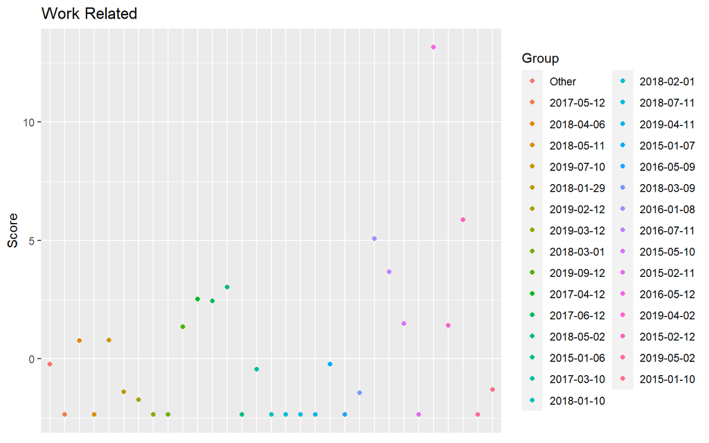

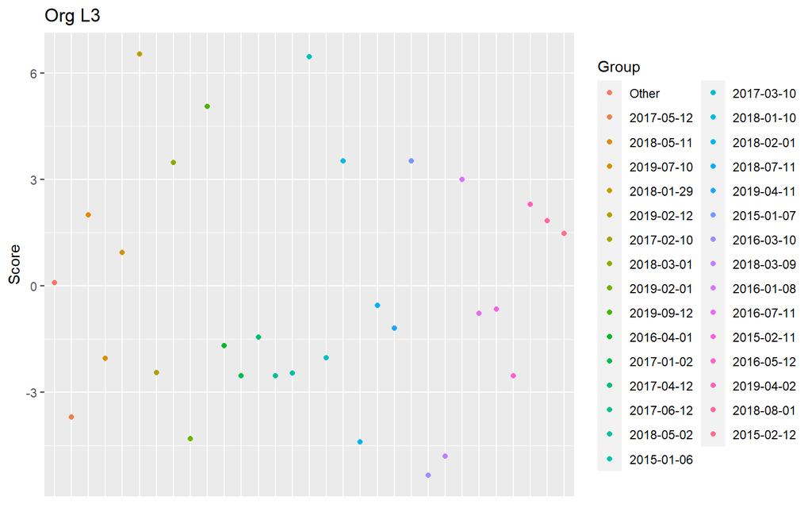

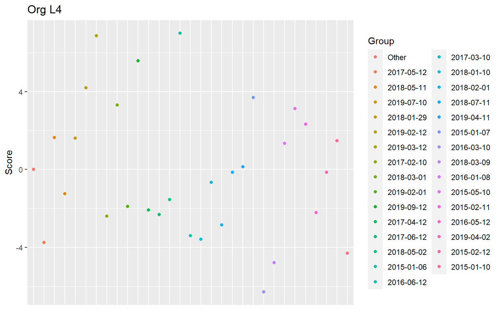

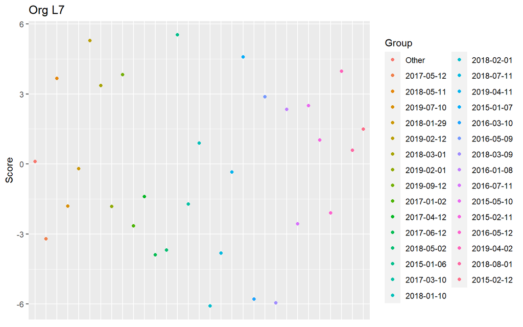

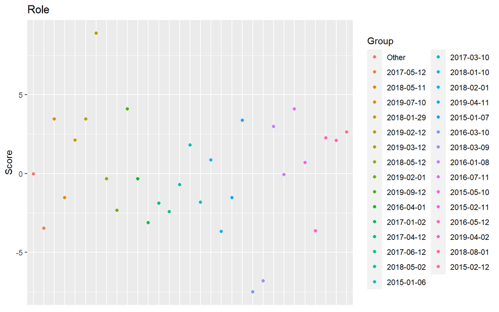

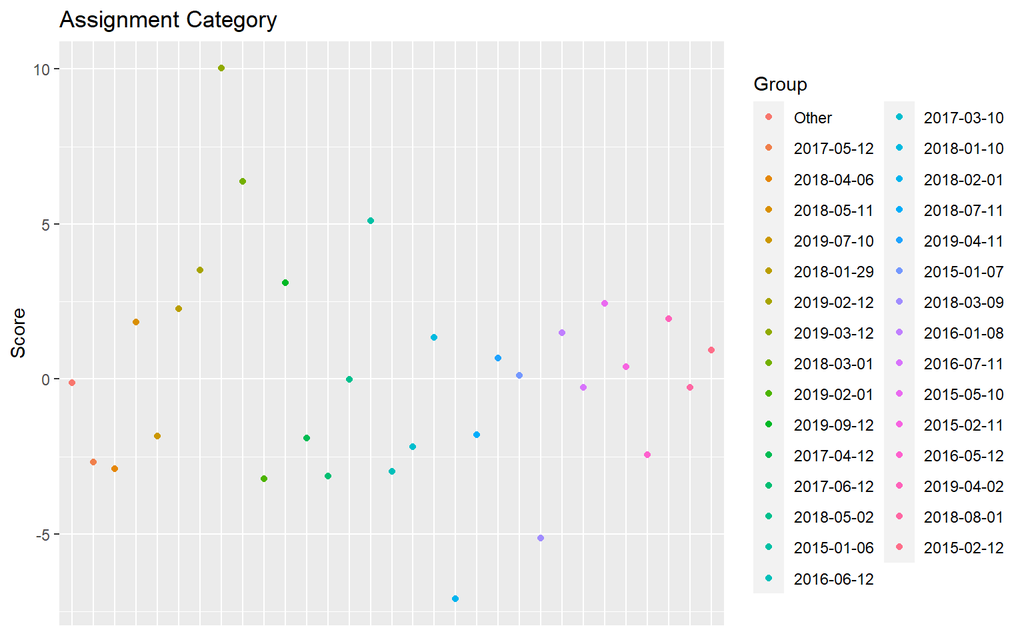

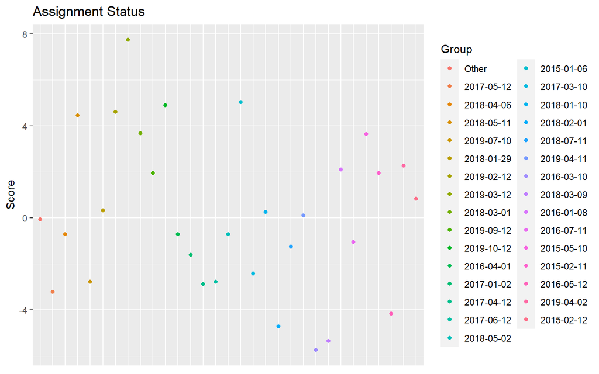

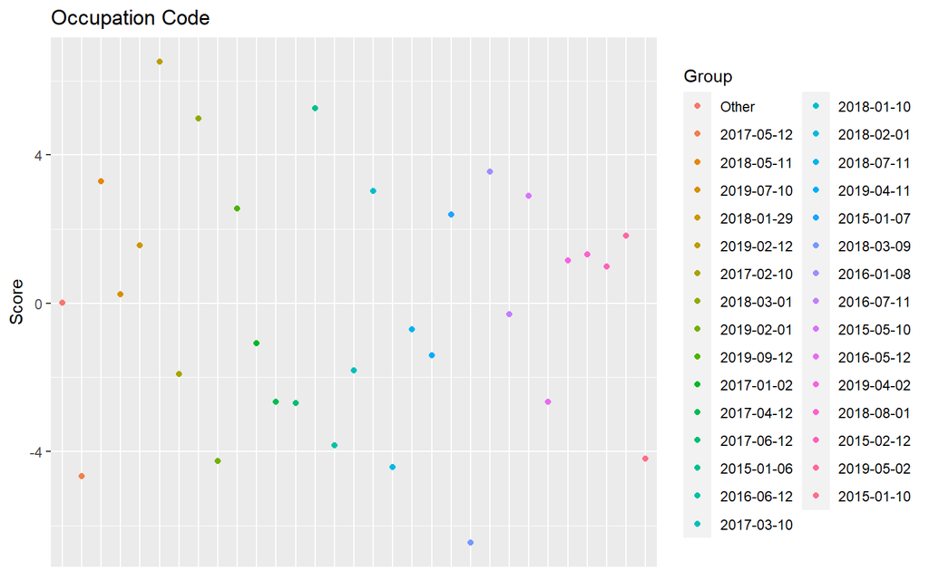

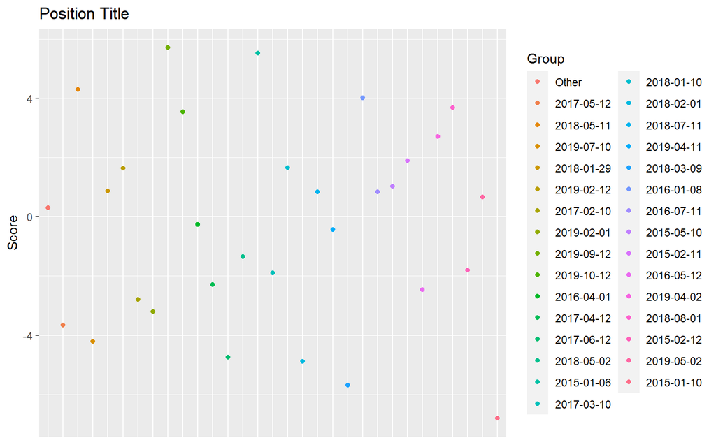

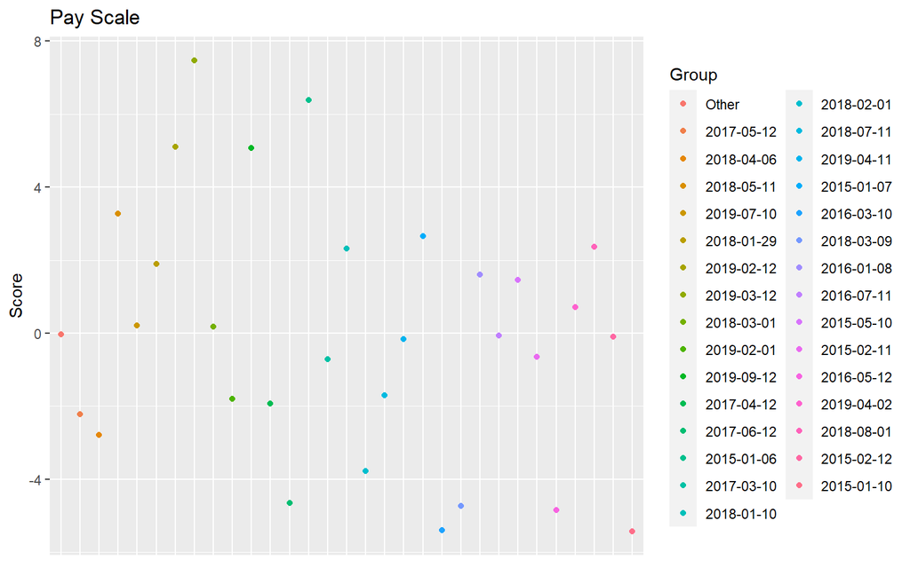

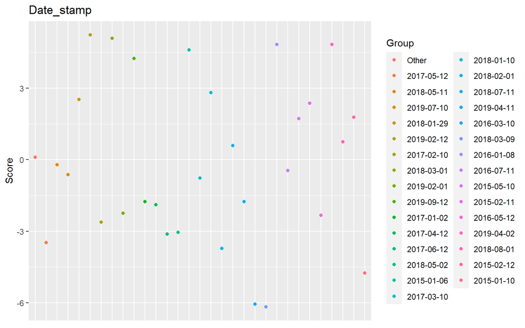

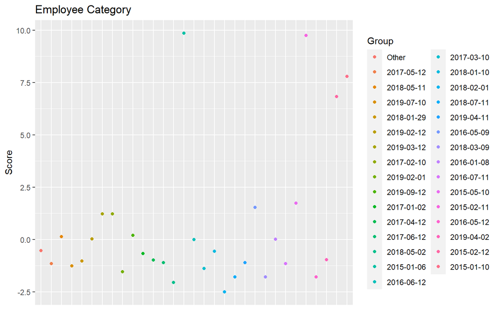

[12 more figures not shown]

## Staff Group on Missing

Figures to summarize Location on missing bias.

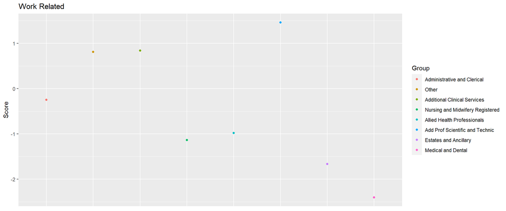

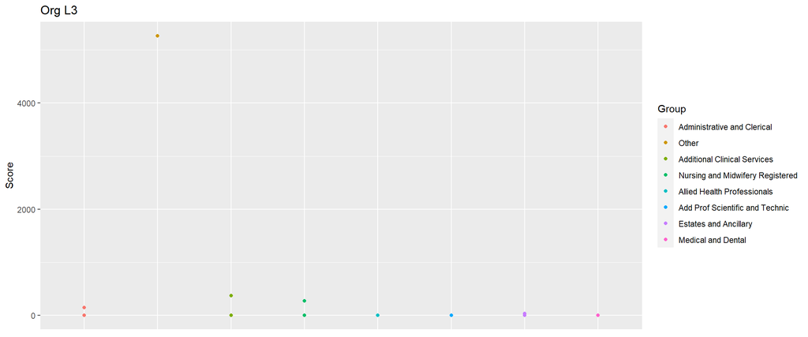

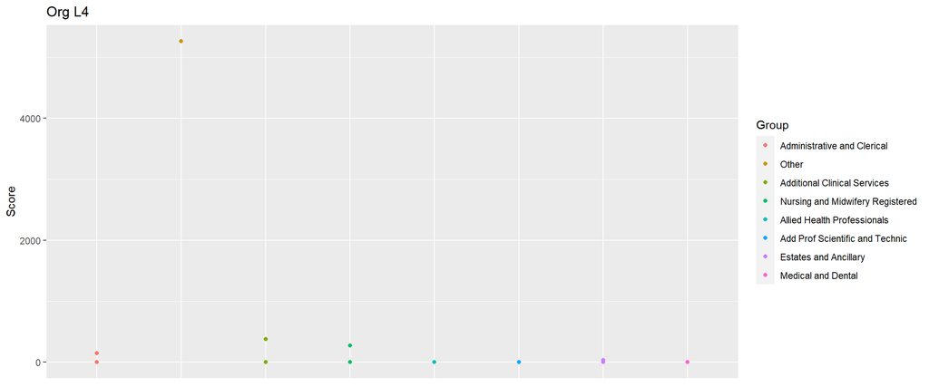

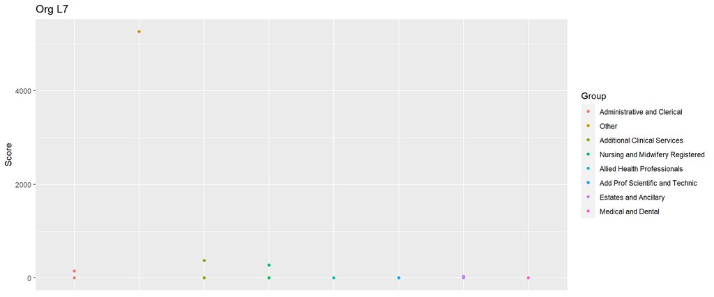

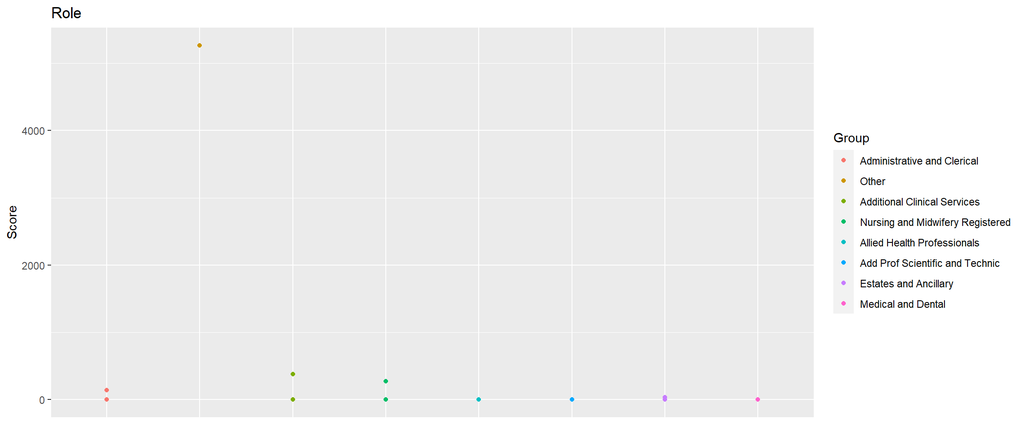

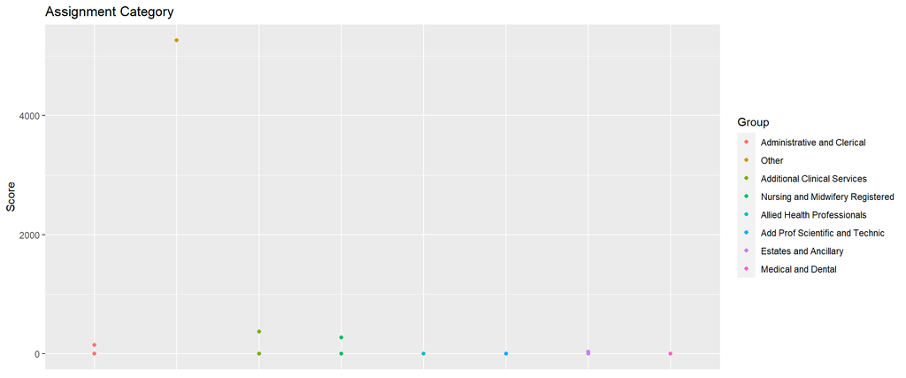

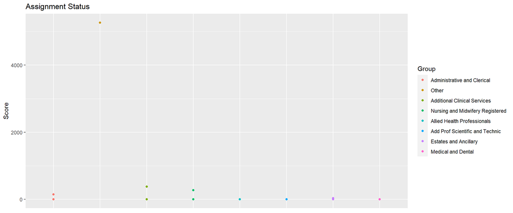

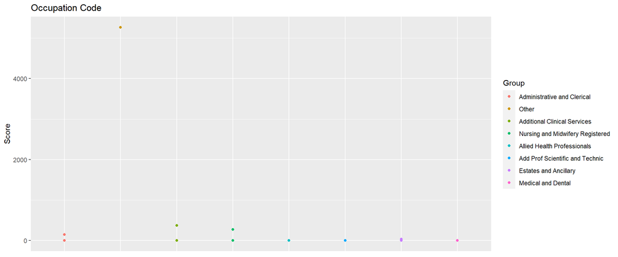

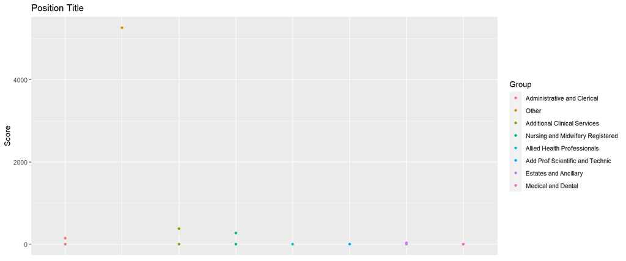

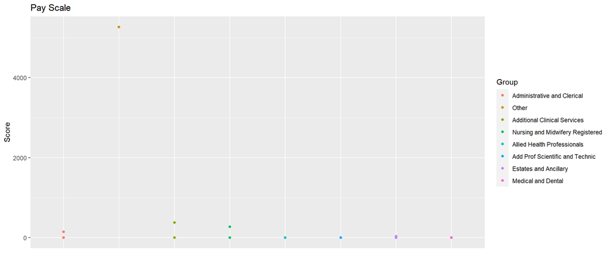

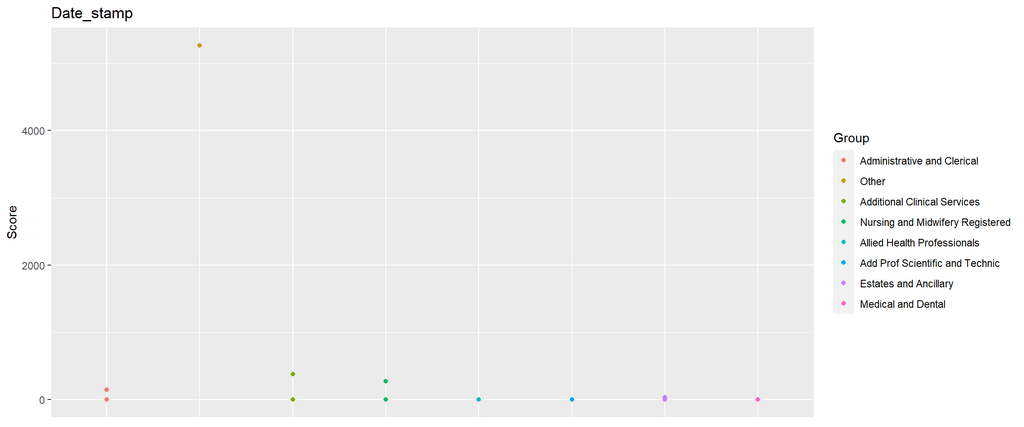

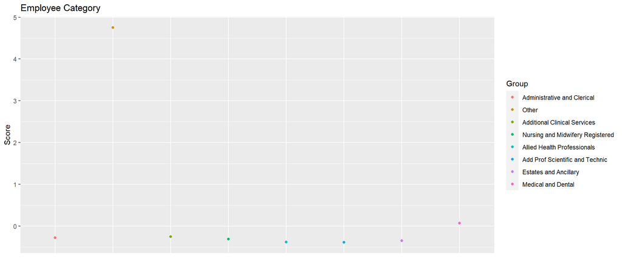

[12 more figures not shown]